# network analysis in R

DataCamp - James Curley

11/28/2020

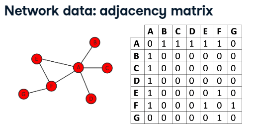

- Nodes/vertices are connected via edges. a `1` in the adjacency matrix indicates an edge exists between nodes in the matrix

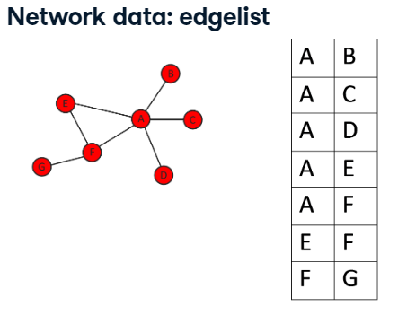

- each row represents an edge between two individual vertices in each column

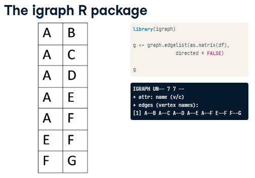

- first number indicates number of vertices (`7`)
- second number indicates number of edges (`7`)
- final row shows all edges in the network

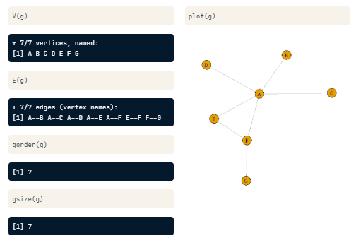

- number and which vertices
  - `V(g)`
- number and which edges
  - `E(g)`
- number of vertices
  - `gorder(g)`
- number of edges
  - `gsize(g)`

**Creating an igraph object**

Here you will learn how to create an `igraph` ‘object’ from data stored in an edgelist. The data are friendships in a group of students. You will also learn how to make a basic visualization of the network.

Each row of the friends dataframe represents an edge in the network.

```r
friends <- read.csv("_data/friends.csv")

# Load igraph
library(igraph)
# Inspect the first few rows of the dataframe 'friends'
head(friends)
```

```
##    name1  name2
## 1 Jessie Sidney
## 2 Jessie  Britt
## 3 Sidney  Britt
## 4 Sidney Donnie
## 5   Karl  Berry
## 6 Sidney   Rene
```

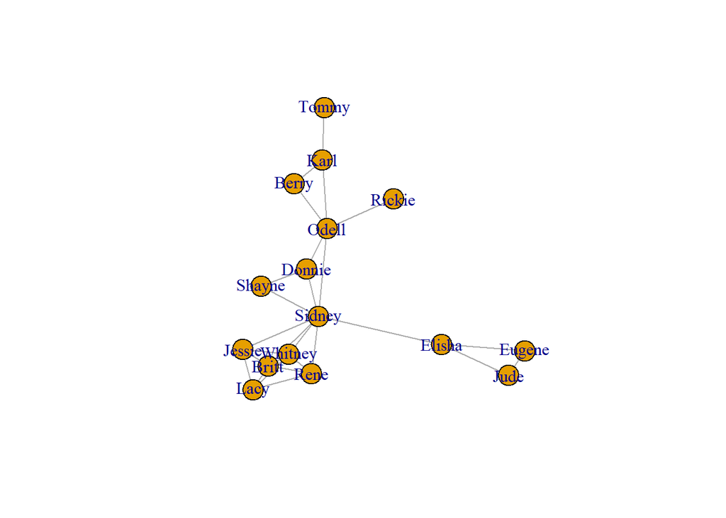

```r
# Convert friends dataframe to a matrix
friends.mat <- as.matrix(friends)

# Convert friends matrix to an igraph object
g <- graph.edgelist(friends.mat, directed = FALSE)

# Make a very basic plot of the network
plot(g)
```

**Counting vertices and edges**

A lot of basic information about a network can be extracted from an `igraph` object. In this exercise you will learn how to count the vertices and edges from a network by applying several functions to the graph object `g`.

Each row of the friends dataframe represents an edge in the network.

```r
# Subset vertices and edges
V(g)
```

```
## + 16/16 vertices, named, from 9e2d785:
##  [1] Jessie  Sidney  Britt   Donnie  Karl    Berry   Rene    Shayne  Elisha
## [10] Whitney Odell   Lacy    Eugene  Jude    Rickie  Tommy
```

```r
E(g)
```

```
## + 27/27 edges from 9e2d785 (vertex names):
##  [1] Jessie --Sidney  Jessie --Britt   Sidney --Britt   Sidney --Donnie
##  [5] Karl   --Berry   Sidney --Rene    Britt  --Rene    Sidney --Shayne
##  [9] Sidney --Elisha  Sidney --Whitney Jessie --Whitney Donnie --Odell
## [13] Sidney --Odell   Rene   --Whitney Donnie --Shayne  Jessie --Lacy
## [17] Rene   --Lacy    Elisha --Eugene  Eugene --Jude    Berry  --Odell
## [21] Odell  --Rickie  Karl   --Odell   Britt  --Lacy    Elisha --Jude
## [25] Whitney--Lacy    Britt  --Whitney Karl   --Tommy
```

```r
# Count number of edges
gsize(g)
```

```
## [1] 27
```

```r
# Count number of vertices
gorder(g)
```

```
## [1] 16
```

**Network attributes**

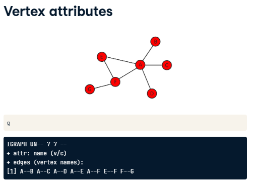

- `attr` indicates that this `igraph` object has attribute `name` defined

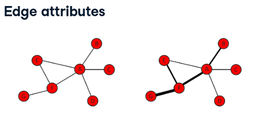

- the most common edge attribute is `weight` between edges, with line thickness indicating weights.

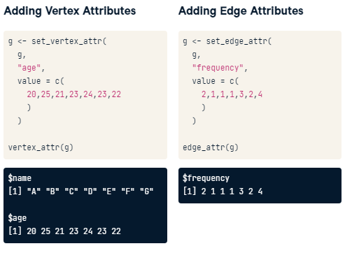

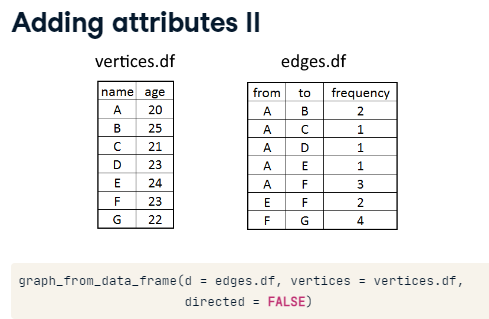

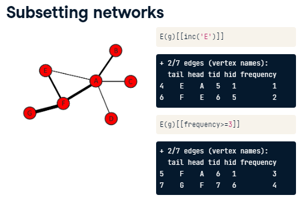

**Node attributes and subsetting**

In this exercise you will learn how to add attributes to vertices in the network and view them.

```r
library(igraph)

# Inspect the objects 'genders' and 'ages'

genders <- c("M", "F", "F", "M", "M", "M", "F", "M", "M", "F", "M", "F", "M", "F", "M", "M")
#dput(genders)
ages <- c(18, 19, 21, 20, 22, 18, 23, 21, 22, 20, 20, 22, 21, 18, 19, 20)
#dput(ages)

genders
```

```
##  [1] "M" "F" "F" "M" "M" "M" "F" "M" "M" "F" "M" "F" "M" "F" "M" "M"
```

```r
ages
```

```
##  [1] 18 19 21 20 22 18 23 21 22 20 20 22 21 18 19 20
```

```r
# Create new vertex attribute called 'gender'
g <- set_vertex_attr(g, "gender", value = genders)

# Create new vertex attribute called 'age'
g <- set_vertex_attr(g, "age", value = ages)

# View all vertex attributes in a list
vertex_attr(g)
```

```
## $name
##  [1] "Jessie"  "Sidney"  "Britt"   "Donnie"  "Karl"    "Berry"   "Rene"
##  [8] "Shayne"  "Elisha"  "Whitney" "Odell"   "Lacy"    "Eugene"  "Jude"
## [15] "Rickie"  "Tommy"
##
## $gender
##  [1] "M" "F" "F" "M" "M" "M" "F" "M" "M" "F" "M" "F" "M" "F" "M" "M"
##
## $age
##  [1] 18 19 21 20 22 18 23 21 22 20 20 22 21 18 19 20
```

```r
# View attributes of first five vertices in a dataframe
V(g)[[1:5]]
```

```
## + 5/16 vertices, named, from 9e2d785:
##     name gender age
## 1 Jessie      M  18
## 2 Sidney      F  19
## 3  Britt      F  21
## 4 Donnie      M  20
## 5   Karl      M  22
```

**Edge attributes and subsetting**

In this exercise you will learn how to add attributes to edges in the network and view them. For instance, we will add the attribute ‘hours’ that represents how many hours per week each pair of friends spend with each other.

```r
library(igraph)

# View hours
hours <- c(1, 2, 2, 1, 2, 5, 5, 1, 1, 3, 2, 1, 1, 5, 1, 2, 4, 1, 3, 1, 1, 1, 4, 1, 3, 3, 4)
#dput(hours)
hours
```

```
##  [1] 1 2 2 1 2 5 5 1 1 3 2 1 1 5 1 2 4 1 3 1 1 1 4 1 3 3 4
```

```r
# Create new edge attribute called 'hours'
g <- set_edge_attr(g, "hours", value = hours)

# View edge attributes of graph object
edge_attr(g)
```

```
## $hours
##  [1] 1 2 2 1 2 5 5 1 1 3 2 1 1 5 1 2 4 1 3 1 1 1 4 1 3 3 4
```

```r
# Find all edges that include "Britt"
E(g)[[inc('Britt')]]
```

```
## + 5/27 edges from 9e2d785 (vertex names):
##      tail    head tid hid hours
## 2  Jessie   Britt   1   3     2
## 3  Sidney   Britt   2   3     2
## 7   Britt    Rene   3   7     5
## 23  Britt    Lacy   3  12     4
## 26  Britt Whitney   3  10     3
```

```r
# Find all pairs that spend 4 or more hours together per week
E(g)[[hours>=4]]
```

```
## + 6/27 edges from 9e2d785 (vertex names):
##      tail    head tid hid hours
## 6  Sidney    Rene   2   7     5
## 7   Britt    Rene   3   7     5
## 14   Rene Whitney   7  10     5
## 17   Rene    Lacy   7  12     4
## 23  Britt    Lacy   3  12     4
## 27   Karl   Tommy   5  16     4
```

**Visualizing attributes**

In this exercise we will learn how to create igraph objects with attributes directly from dataframes and how to visualize attributes in plots. We will use a second network of friendship connections between students.

```r
library(igraph)

friends1_edges <- read.csv("_data/friends1_edges.csv")
friends1_nodes <- read.csv("_data/friends1_nodes.csv")

# Create an igraph object with attributes directly from dataframes
g1 <- graph_from_data_frame(d = friends1_edges, vertices = friends1_nodes, directed = FALSE)


# Subset edges greater than or equal to 5 hours
E(g1)[[hours >= 5]]
```

```
## + 4/25 edges from 9e77c77 (vertex names):
##         tail      head tid hid hours
## 5     Kelley Valentine   3   6     5
## 8     Ronald   Jasmine   4   8     5
## 12 Valentine     Perry   6  15     5
## 15   Jasmine      Juan   8   9     6
```

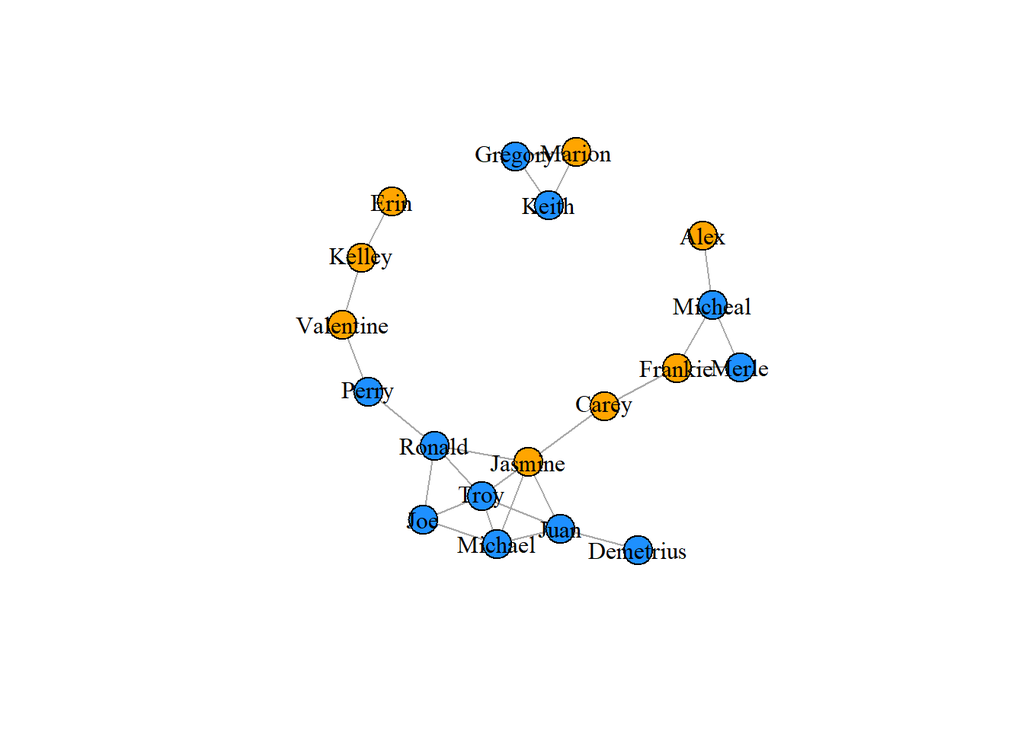

```r
# Set vertex color by gender
V(g1)$color <- ifelse(V(g1)$gender == "F", "orange", "dodgerblue")

# Plot the graph
plot(g1, vertex.label.color = "black")
```

**Network visualization**

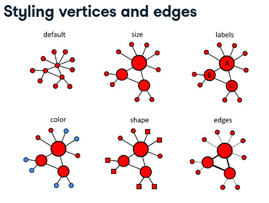

**Choosing the appropriate layout**

- minimize edge crossing
- do not allow vertices to overlap
- make edge lengths as uniform as possible
- increase symmetry of the network as much as possible
- position more influential nodes towards the center

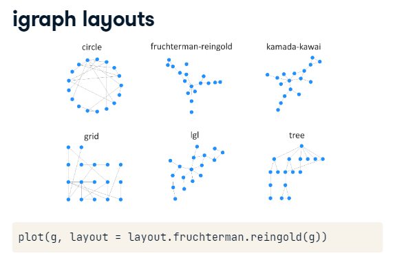

**igraph network layouts**

The `igraph` package provides several built in layout algorithms for network visualization. Depending upon the size of a given network different layouts may be more effective in communicating the structure of the network. Ideally the best layout is the one that minimizes the number of edges that cross each other in the network. In this exercise you will explore just a few of the many default layout algorithms. Re-executing the code for each plot will lead to a slightly different version of the same layout type. Doing this a few times can help to find the best looking visualization for your network.

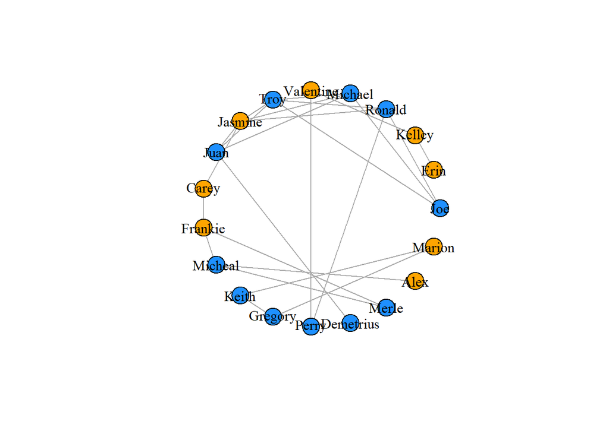

```r
library(igraph)

# Plot the graph object g1 in a circle layout
plot(g1, vertex.label.color = "black", layout = layout_in_circle(g1))
```

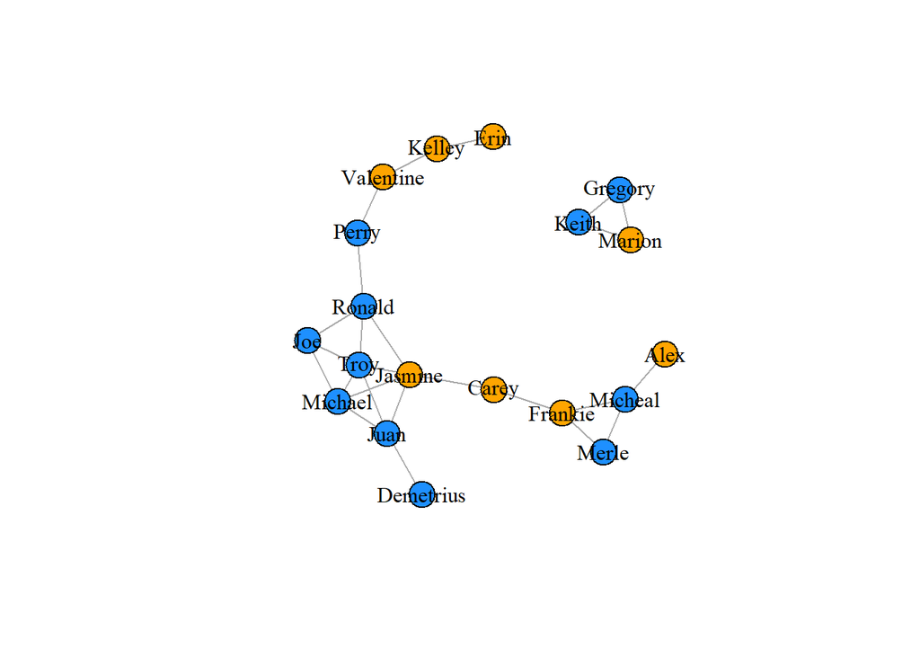

```r
# Plot the graph object g1 in a Fruchterman-Reingold layout
plot(g1, vertex.label.color = "black", layout = layout_with_fr(g1))
```

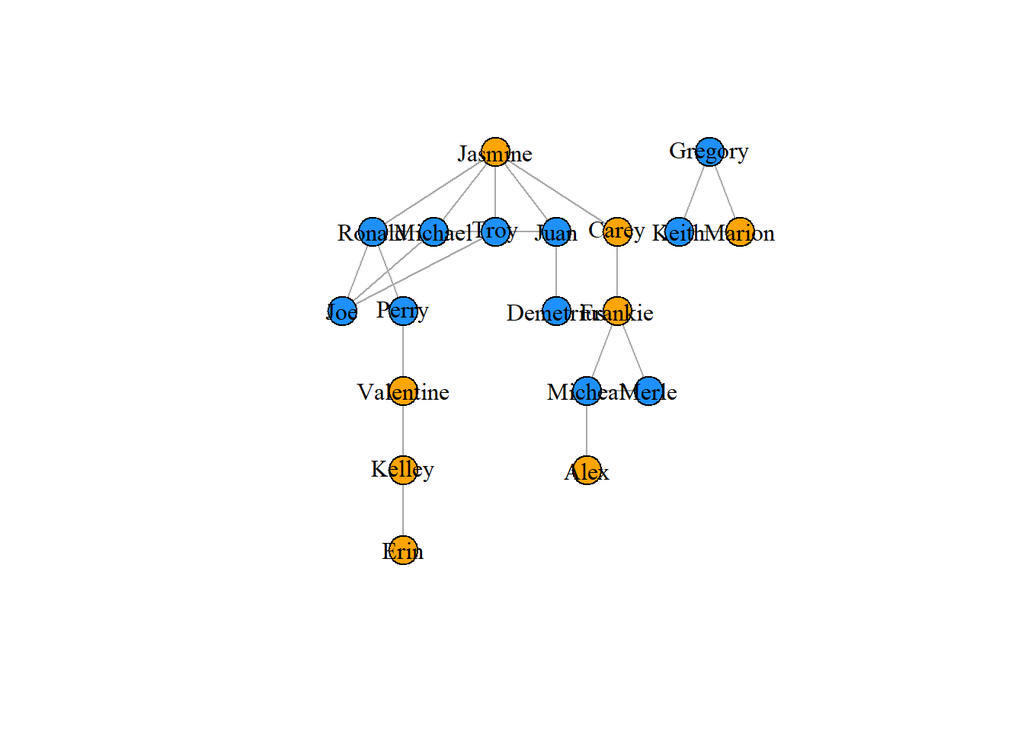

```r
# Plot the graph object g1 in a Tree layout
m <- layout_as_tree(g1)
plot(g1, vertex.label.color = "black", layout = m)
```

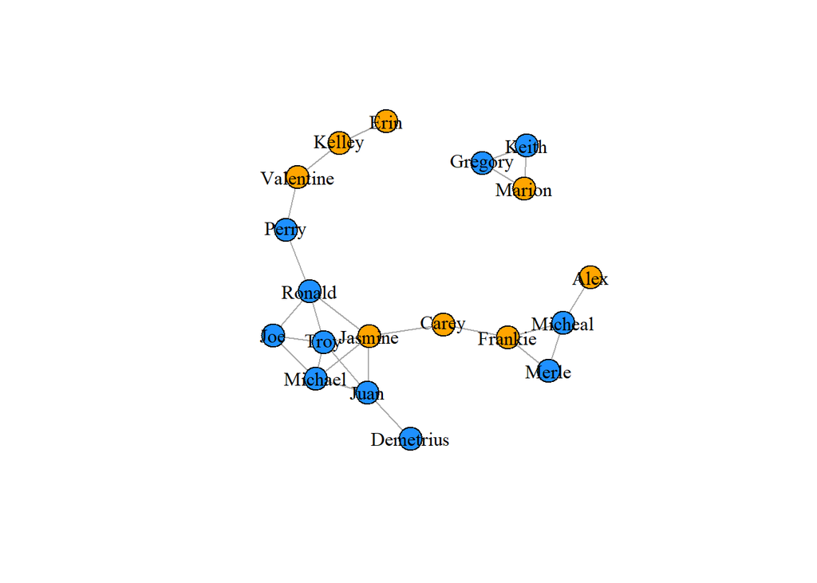

```r
# Plot the graph object g1 using igraph's chosen layout
m1 <- layout_nicely(g1)
plot(g1, vertex.label.color = "black", layout = m1)
```

**Visualizing edges**

In this exercise you will learn how to change the size of edges in a network based on their weight, as well as how to remove edges from a network which can sometimes be helpful in more effectively visualizing large and highly clustered networks. In this introductory chapter, we have just scratched the surface of what’s possible in visualizing `igraph` networks. You will continue to develop these skills in future chapters.

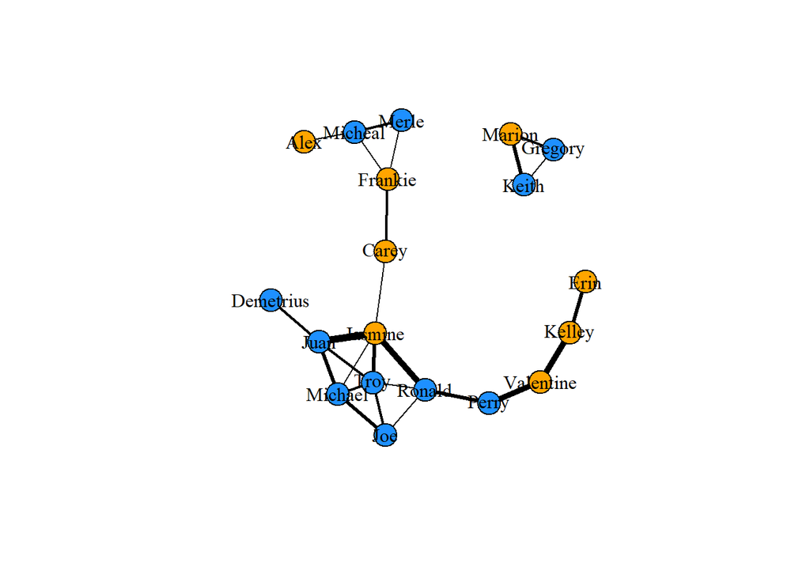

```r
library(igraph)

# Create a vector of weights based on the number of hours each pair spend together
w1 <- E(g1)$hours

# Plot the network varying edges by weights
m1 <- layout_nicely(g1)
plot(g1,
        vertex.label.color = "black",
        edge.color = 'black',
        edge.width = w1,
        layout = m1)
```

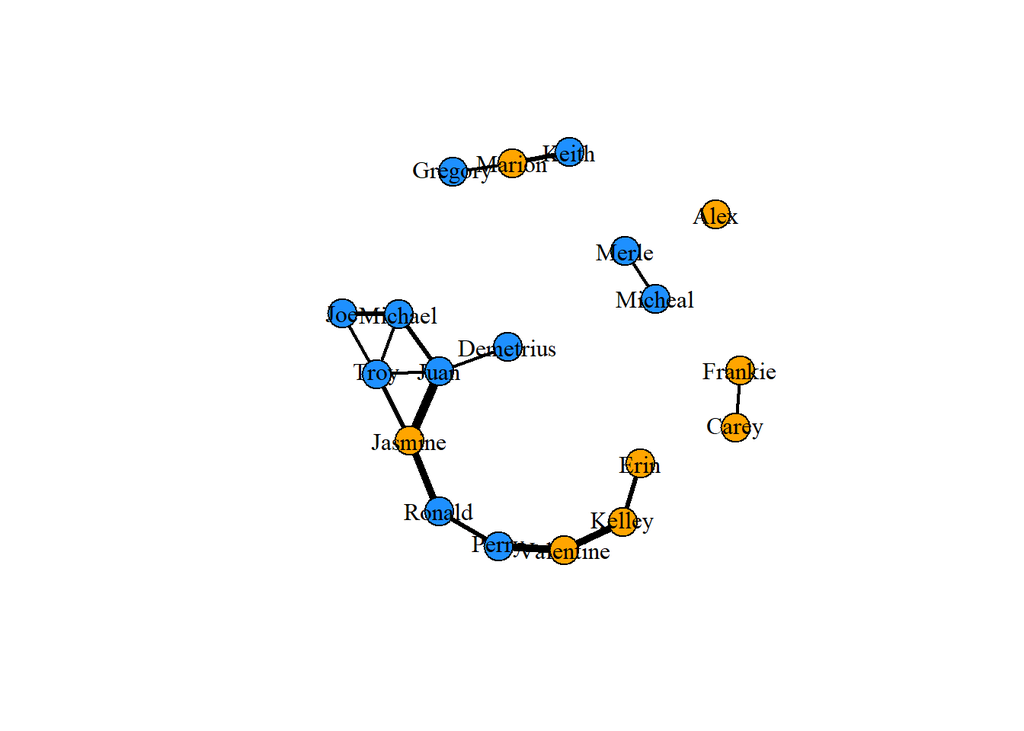

```r
# Create a new igraph object by deleting edges that are less than 2 hours long
g2 <- delete_edges(g1, E(g1)[hours < 2])


# Plot the new graph
w2 <- E(g2)$hours
m2 <- layout_nicely(g2)

plot(g2,
     vertex.label.color = "black",
     edge.color = 'black',
     edge.width = w2,
     layout = m2)
```

**Directed networks**

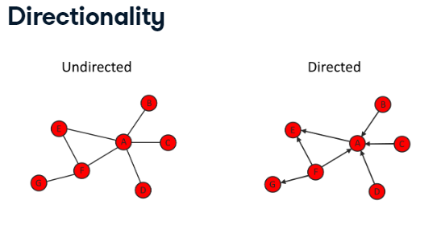

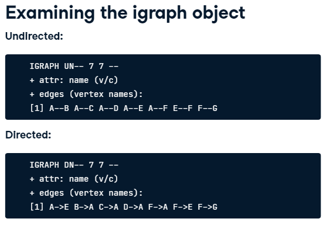

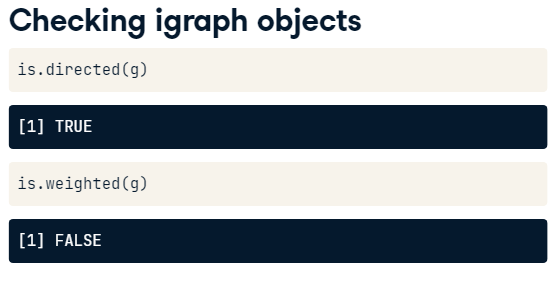

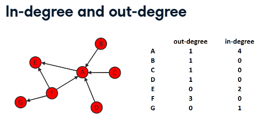

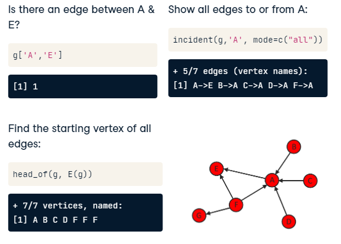

**Directed igraph objects**

In this exercise you will learn how to create a directed graph from a dataframe, how to inspect whether a graph object is directed and/or weighted and how to extract those vertices at the beginning and end of directed edges.

```r
library(igraph)

measles <- read.csv("_data/measles.csv")
head(measles)
```

```
##   from to
## 1   45  1
## 2   45  2
## 3  172  3
## 4  180  4
## 5   45  5
## 6  180  6
```

```r
tail(measles)
```

```
##     from  to
## 179  184 182
## 180  184 183
## 181   82 185
## 182   45 186
## 183   82 187
## 184  175 188
```

```r
# Get graph object
g <- graph_from_data_frame(measles, directed = TRUE)

# Is the graph directed?
is.directed(g)
```

```
## [1] TRUE
```

```r
# Is the graph weighted?
is.weighted(g)
```

```
## [1] FALSE
```

```r
# Where does each edge originate from?
table(head_of(g, E(g)))
```

```
##
##   1   2   3   4   5   6   7   8   9  10  11  12  13  14  15  17  18  19  20  21
##   1   1   1   1   1   1   1   1   1   1   1   1   1   1   1   1   1   1   1   1
##  22  23  24  25  26  27  28  29  30  31  32  33  34  35  36  37  38  39  40  41
##   1   1   1   1   1   1   1   1   1   1   1   1   1   1   1   1   1   1   1   1
##  42  43  44  45  46  47  48  49  50  51  52  53  54  55  56  57  58  61  62  63
##   1   1   1   1   1   1   1   1   1   1   1   1   1   1   1   1   1   1   1   1
##  64  65  66  67  68  69  70  71  72  73  74  75  76  77  78  79  80  81  82  83
##   1   1   1   1   1   1   1   1   1   1   1   1   1   1   1   1   1   1   1   1
##  84  85  86  87  88  89  90  91  92  93  94  95  96  97  98  99 100 101 102 103
##   1   1   1   1   1   1   1   1   1   1   1   1   1   1   1   1   1   1   1   1
## 104 105 106 107 108 109 110 111 112 113 114 115 116 117 118 119 120 121 122 123
##   1   1   1   1   1   1   1   1   1   1   1   1   1   1   1   1   1   1   1   1
## 124 125 126 127 128 129 130 131 132 133 134 135 136 137 138 139 140 141 142 143
##   1   1   1   1   1   1   1   1   1   1   1   1   1   1   1   1   1   1   1   1
## 144 145 146 147 148 149 150 151 152 153 154 155 156 157 158 159 160 161 162 163
##   1   1   1   1   1   1   1   1   1   1   1   1   1   1   1   1   1   1   1   1
## 164 165 166 167 168 169 170 171 172 173 174 175 176 177 178 179 180 181 182 183
##   1   1   1   1   1   1   1   1   1   1   1   1   1   1   1   1   1   1   1   1
## 184 185 186 187
##   1   1   1   1
```

**Identifying edges for each vertex**

In this exercise you will learn how to identify particular edges. You will learn how to determine if an edge exists between two vertices as well as finding all vertices connected in either direction to a given vertex.

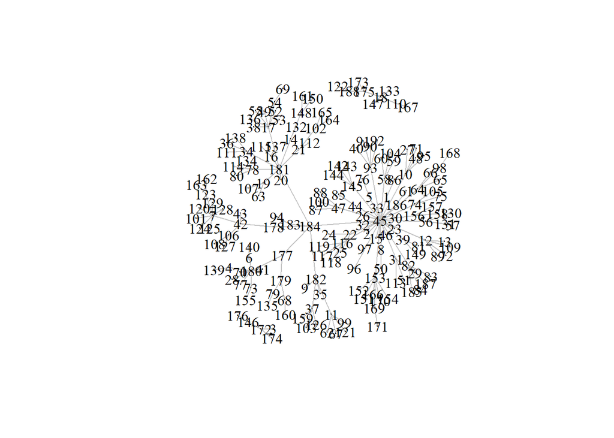

```
## [1] 1
```

```r
library(igraph)

# Make a basic plot
plot(g,
     vertex.label.color = "black",
     edge.color = 'gray77',
     vertex.size = 0,
     edge.arrow.size = 0.1,
     layout = layout_nicely(g))

# Is there an edge going from vertex 184 to vertex 178?
g['184', '178']
```

```r
# Is there an edge going from vertex 178 to vertex 184?
g['178', '184']
```

```
## [1] 0
```

```r
# Show all edges going to or from vertex 184
incident(g, '184', mode = c("all"))
```

```
## + 6/184 edges from 9f376dc (vertex names):
## [1] 184->45  184->182 184->181 184->178 184->183 184->177
```

```r
# Show all edges going out from vertex 184
incident(g, '184', mode = c("out"))
```

```
## + 6/184 edges from 9f376dc (vertex names):
## [1] 184->45  184->182 184->181 184->178 184->183 184->177
```

**Relationships between vertices**

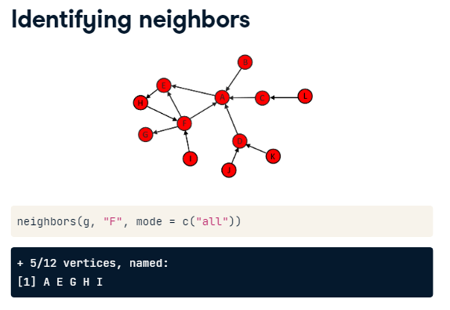

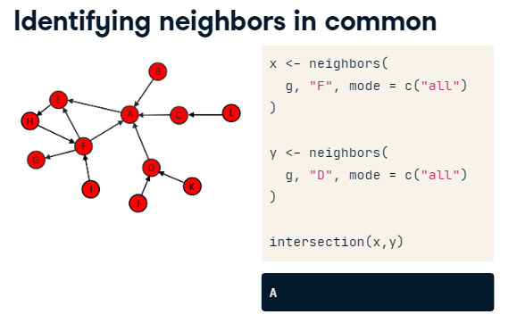

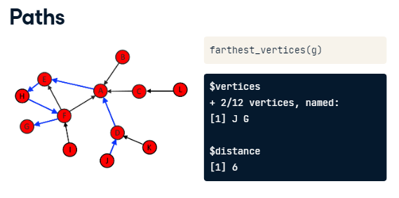

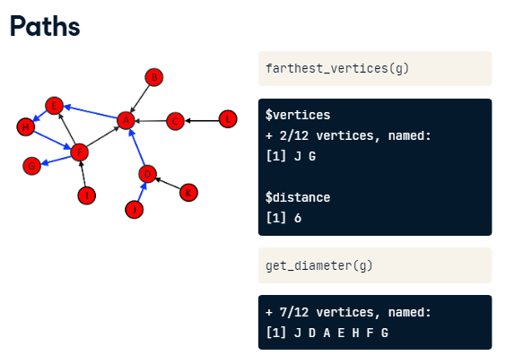

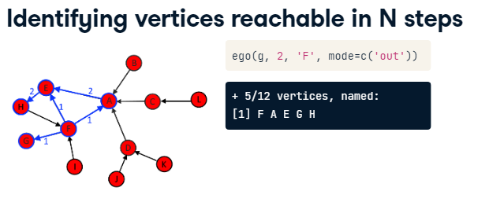

**Neighbors**